# Virginia Election Project

Author

Sejal Govindarao

# Comparing Virginia Election Results by County

In this analysis walkthrough, we will be looking at Virginia election results by county. We will compare the 2020 Presidential Election and 2021 Gubernatorial Election – this is particularly interesting because Biden, a Democrat, won in 2020 while Youngkin, a Republican, won in 2021.

In this first table, we will see a breakdown by county of the margins by which Trump, Biden, McAuliffe and Youngkin faired. Check out the interactive data table!

```r
DT::datatable(joined_vacomparison)
```

|  | locality | biden | trump | biden_pct | trump_pct | youngkin | mcauliffe | pct_youngkin | pct_mcauliffe |
| --- | --- | --- | --- | --- | --- | --- | --- | --- | --- |
| 1 | ACCOMACK COUNTY | 7578 | 9172 | 44.68 | 54.07 | 7878 | 4948 | 61.08 | 38.37 |
| 2 | ALBEMARLE COUNTY | 42466 | 20804 | 65.68 | 32.18 | 19141 | 31919 | 37.21 | 62.05 |
| 3 | ALEXANDRIA CITY | 66240 | 14544 | 80.28 | 17.63 | 14013 | 43866 | 24.02 | 75.2 |
| 4 | ALLEGHANY COUNTY | 2243 | 5859 | 27.34 | 71.43 | 4530 | 1518 | 74.52 | 24.97 |
| 5 | AMELIA COUNTY | 2411 | 5390 | 30.55 | 68.29 | 4720 | 1617 | 74.19 | 25.42 |
| 6 | AMHERST COUNTY | 5672 | 11041 | 33.35 | 64.93 | 9731 | 3897 | 71 | 28.43 |
| 7 | APPOMATTOX COUNTY | 2418 | 6702 | 26.09 | 72.31 | 5971 | 1438 | 80.26 | 19.33 |
| 8 | ARLINGTON COUNTY | 105344 | 22318 | 80.6 | 17.08 | 21548 | 73013 | 22.63 | 76.67 |
| 9 | AUGUSTA COUNTY | 10840 | 30714 | 25.64 | 72.65 | 26196 | 7231 | 77.93 | 21.51 |
| 10 | BATH COUNTY | 646 | 1834 | 25.83 | 73.33 | 1539 | 396 | 79.04 | 20.34 |

[output cut: 123 more lines]

This next table adds a column at the end, illustrating how many points Youngkin held over Trump in each respective county.

```r
joined_vacomparison = joined_vacomparison %>%
  mutate(YoungkinADV = pct_youngkin - trump_pct)
head(joined_vacomparison)
```

```
# A tibble: 6 × 10
  locality   biden trump biden…¹ trump…² young…³ mcaul…⁴ pct_y…⁵ pct_m…⁶ Young…⁷
  <chr>      <dbl> <dbl>   <dbl>   <dbl>   <int>   <int>   <dbl>   <dbl>   <dbl>
1 ACCOMACK …  7578  9172    44.7    54.1    7878    4948    61.1    38.4    7.01
2 ALBEMARLE… 42466 20804    65.7    32.2   19141   31919    37.2    62.0    5.03
3 ALEXANDRI… 66240 14544    80.3    17.6   14013   43866    24.0    75.2    6.39
4 ALLEGHANY…  2243  5859    27.3    71.4    4530    1518    74.5    25.0    3.09
5 AMELIA CO…  2411  5390    30.6    68.3    4720    1617    74.2    25.4    5.90
6 AMHERST C…  5672 11041    33.4    64.9    9731    3897    71      28.4    6.07
# … with abbreviated variable names ¹biden_pct, ²trump_pct, ³youngkin,
#   ⁴mcauliffe, ⁵pct_youngkin, ⁶pct_mcauliffe, ⁷YoungkinADV
```

Next, we have a bar chart that hones in on the analysis we saw in the prior table – this chart focuses on the top 5 counties where Youngkin in 2021 held the highest percentage of the vote as compared to Trump in 2020.

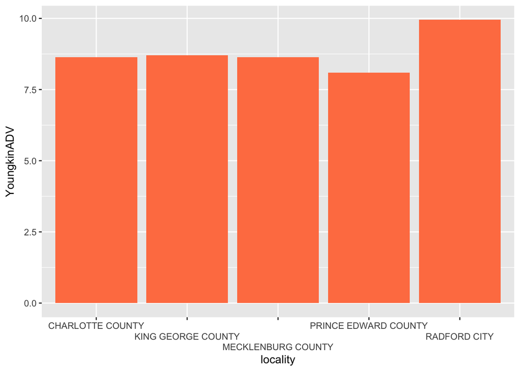

```r
TOP5 <- joined_vacomparison %>%
  arrange(desc(YoungkinADV)) %>%
  slice(1:5)

ggplot(TOP5, aes(x = locality, y = YoungkinADV)) +
  geom_bar(stat="identity", fill="coral")+
  scale_x_discrete(guide = guide_axis(n.dodge=3))
```

This bar chart isolates Youngkin in 2021, illustrating the top 5 counties he performed best in.

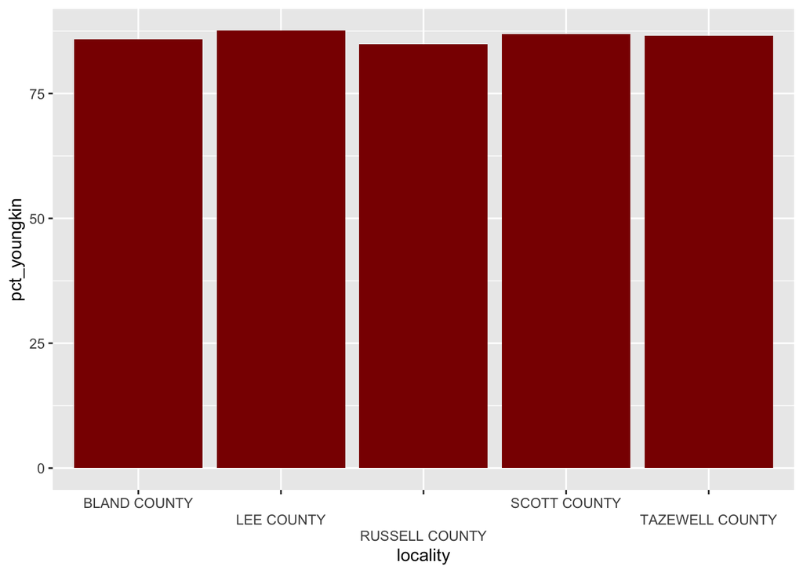

```r
YOUNGKIN_5 <- joined_vacomparison %>%
  arrange(desc(pct_youngkin)) %>%
  slice(1:5)

ggplot(YOUNGKIN_5, aes(x = locality, y = pct_youngkin)) +
  geom_bar(stat="identity", fill="darkred")+
  scale_x_discrete(guide = guide_axis(n.dodge=3))
```

Similarly, this bar chart illustrates the top 5 counties McAuliffe performed best in during the 2021 VA Election.

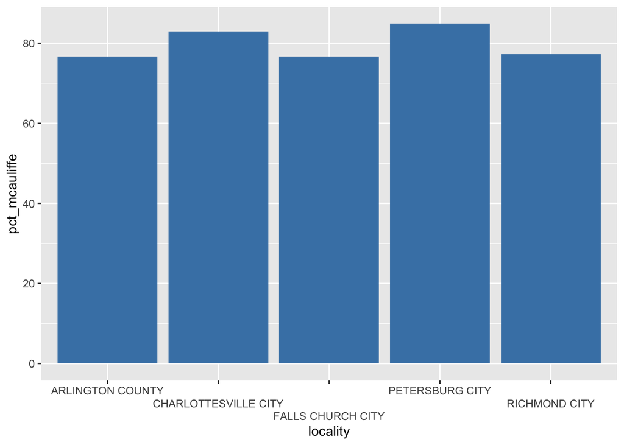

```r
MCAULIFFE_5 <- joined_vacomparison %>%
  arrange(desc(pct_mcauliffe)) %>%
  slice(1:5)

ggplot(MCAULIFFE_5, aes(x = locality, y = pct_mcauliffe)) +
  geom_bar(stat="identity", fill="steelblue")+
  scale_x_discrete(guide = guide_axis(n.dodge=3))
```

Here we see a comparison between Biden and McAuliffe, illustrating the top 5 counties Biden outperformed McAuliffe in.

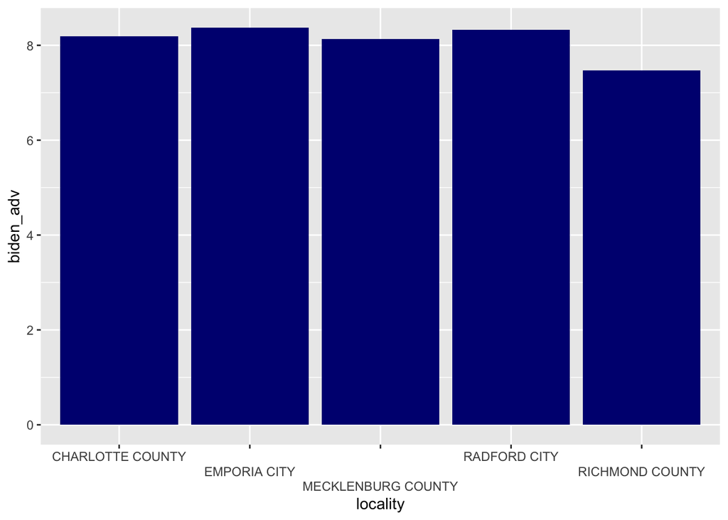

```r
joined_vacomparison = joined_vacomparison %>%
  mutate(biden_adv = biden_pct - pct_mcauliffe)

BIDEN_ADV <- joined_vacomparison %>%
  arrange(desc(biden_adv)) %>%
  slice(1:5)

ggplot(BIDEN_ADV, aes(x = locality, y = biden_adv)) +
  geom_bar(stat="identity", fill="navy")+
  scale_x_discrete(guide = guide_axis(n.dodge=3))
```

We now see the top 5 counties in Virginia Biden outperformed Trump in 2020.

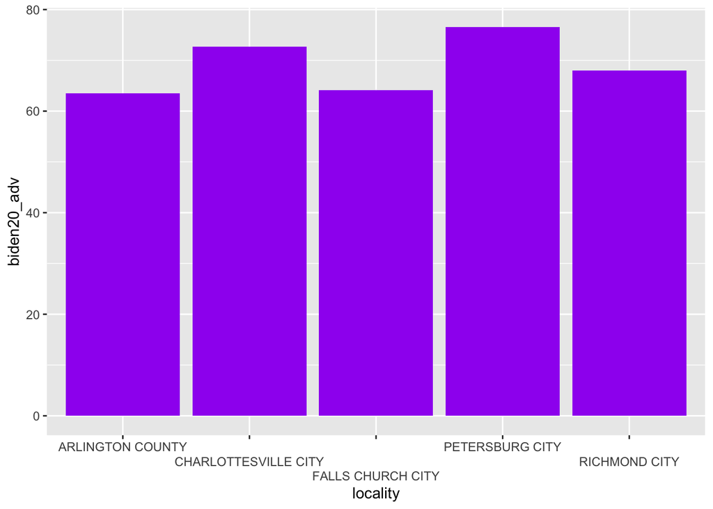

```r
joined_vacomparison = joined_vacomparison %>%
  mutate(biden20_adv = biden_pct - trump_pct)

BIDEN20_ADV <- joined_vacomparison %>%
  arrange(desc(biden20_adv)) %>%
  slice(1:5)

ggplot(BIDEN20_ADV, aes(x = locality, y = biden20_adv)) +
  geom_bar(stat="identity", fill="purple")+
  scale_x_discrete(guide = guide_axis(n.dodge=3))
```

And, conversely, here are the top 5 counties in Virginia Trump outperformed Biden in 2020.

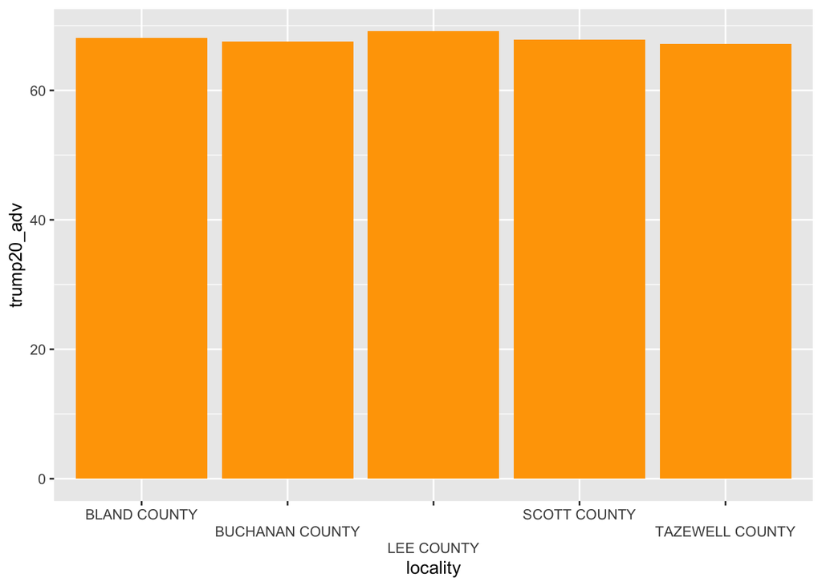

```r
joined_vacomparison = joined_vacomparison %>%
  mutate(trump20_adv = trump_pct - biden_pct)

TRUMP20_ADV <- joined_vacomparison %>%
  arrange(desc(trump20_adv)) %>%
  slice(1:5)

ggplot(TRUMP20_ADV, aes(x = locality, y = trump20_adv)) +
  geom_bar(stat="identity", fill="orange")+
  scale_x_discrete(guide = guide_axis(n.dodge=3))
```